# PW4

PINPIN Pierrick

2022-10-07

## Question 1

```r
dataset <- read.csv(file= "E:/ESILV/S7/Machine Learning/PW/PW4/Social_Network_Ads.csv")

View(dataset)
```

## Question 2

```r
str(dataset)
```

```
## 'data.frame':    400 obs. of  5 variables:
##  $ User.ID        : int  15624510 15810944 15668575 15603246 15804002 15728773 15598044 15694829 15600575 15727311 ...
##  $ Gender         : chr  "Male" "Male" "Female" "Female" ...
##  $ Age            : num  19 35 26 27 19 27 27 32 25 35 ...
##  $ EstimatedSalary: num  19000 20000 43000 57000 76000 58000 84000 150000 33000 65000 ...
##  $ Purchased      : int  0 0 0 0 0 0 0 1 0 0 ...
```

```r
summary(dataset)
```

```
##     User.ID            Gender               Age        EstimatedSalary
##  Min.   :15566689   Length:400         Min.   :18.00   Min.   : 15000
##  1st Qu.:15626764   Class :character   1st Qu.:29.75   1st Qu.: 43000
##  Median :15694342   Mode  :character   Median :37.00   Median : 70000
##  Mean   :15691540                      Mean   :37.66   Mean   : 69743
##  3rd Qu.:15750363                      3rd Qu.:46.00   3rd Qu.: 88000
##  Max.   :15815236                      Max.   :60.00   Max.   :150000
##    Purchased
##  Min.   :0.0000
##  1st Qu.:0.0000
##  Median :0.0000
##  Mean   :0.3575
##  3rd Qu.:1.0000
##  Max.   :1.0000
```

We can see that this dataset is composed of 400 observations and 5 variables, so, 400 lines and 5 columns. The function str() describe the dataset in its entirety: the types of the variables (int, num, char…). The function summary summarize the data. It gives us the min, max and all the quartiles of every variable.

## Question 3

```r
library("caTools")
set.seed(123)

split = sample.split(dataset$Purchased, SplitRatio=0.8)
training_set = subset(dataset,split == TRUE)
test_set = subset(dataset, split == FALSE)

View(training_set)
View(test_set)
```

Splits the dataset into 2 parts with a split ratio of 80% for training_set and 20% for the test_set.

## Question 4

```r
training_set[c(3,4)] = scale(training_set[c(3,4)])
test_set[c(3,4)] = scale(test_set[c(3,4)])
```

Scales the variables Age and EstimatedSalary.

## Question 5

```r
model = glm(Purchased~Age,data= training_set, family= "binomial")

summary(model)
```

```
##
## Call:
## glm(formula = Purchased ~ Age, family = "binomial", data = training_set)
##
## Deviance Residuals:
##     Min       1Q   Median       3Q      Max
## -2.5775  -0.6626  -0.2878   0.5237   2.4568
##
## Coefficients:
##             Estimate Std. Error z value Pr(>|z|)
## (Intercept)  -0.9368     0.1627  -5.759 8.47e-09 ***
## Age           2.0264     0.2311   8.768  < 2e-16 ***
## ---
## Signif. codes:  0 '***' 0.001 '**' 0.01 '*' 0.05 '.' 0.1 ' ' 1
##
## (Dispersion parameter for binomial family taken to be 1)
##
##     Null deviance: 416.79  on 319  degrees of freedom
## Residual deviance: 266.70  on 318  degrees of freedom
## AIC: 270.7
##
## Number of Fisher Scoring iterations: 5
```

Simple Logistic regression model.

## Question 6

We chose ‘binomial’ because this is a generalized linear model where the variable to predict is binary (0 or 1). That is why we chose the Binomial law.

## Question 7

```r
summary(model)$coefficients
```

```
##               Estimate Std. Error   z value     Pr(>|z|)
## (Intercept) -0.9367914  0.1626711 -5.758807 8.471052e-09
## Age          2.0264333  0.2311242  8.767724 1.823143e-18
```

We can see that the equation of the logistic regression of ‘Purchased’ in function of ‘Age’ is: y= exp(-0.9367914 + 2.0264333 * Age)/ (1 + exp(-0.9367914 + 2.0264333 * Age)) We can identify the coefficients: b0= -0.9367914 ; b1= 2.0264333

## Question 8

```r
summary(model)
```

```
##
## Call:
## glm(formula = Purchased ~ Age, family = "binomial", data = training_set)
##
## Deviance Residuals:
##     Min       1Q   Median       3Q      Max
## -2.5775  -0.6626  -0.2878   0.5237   2.4568
##
## Coefficients:
##             Estimate Std. Error z value Pr(>|z|)
## (Intercept)  -0.9368     0.1627  -5.759 8.47e-09 ***
## Age           2.0264     0.2311   8.768  < 2e-16 ***
## ---
## Signif. codes:  0 '***' 0.001 '**' 0.01 '*' 0.05 '.' 0.1 ' ' 1
##
## (Dispersion parameter for binomial family taken to be 1)
##
##     Null deviance: 416.79  on 319  degrees of freedom
## Residual deviance: 266.70  on 318  degrees of freedom
## AIC: 270.7
##
## Number of Fisher Scoring iterations: 5
```

We can see that the p-value smaller than 2e-16 which is smaller than 0.05, so Age is a significant variable for this model. Moreover, the Signif. codes support this.

## Question 9

```r
summary(model)$aic
```

```
## [1] 270.695
```

We have a AIC (Akaike Information Criterion) of: 270.695.

## Question 10

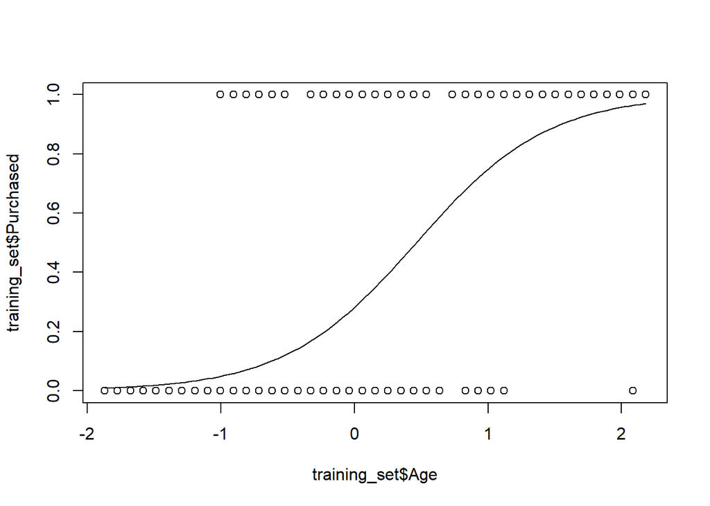

```r
plot(training_set$Age, training_set$Purchased)
curve(predict(model, data.frame(Age= x), type= 'response'), add= TRUE)
```

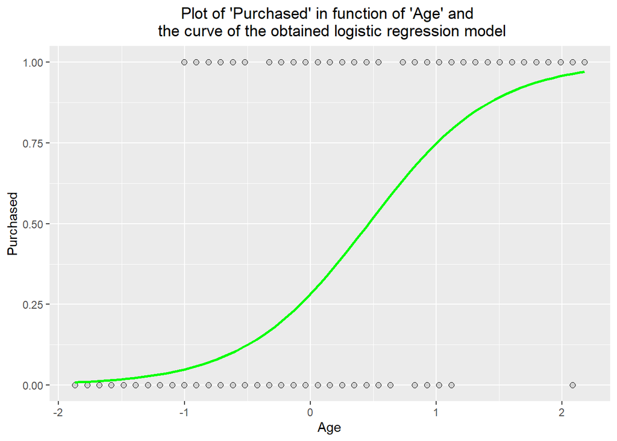

```r
library(ggplot2)

ggplot(training_set, aes(x= Age, y= Purchased)) + geom_point(shape = 21, fill = "lightgray", size= 2) +
  stat_smooth(method="glm", color="green", se= FALSE, method.args=  list(family= binomial)) +
  ggtitle("Plot of 'Purchased' in function of 'Age' and \n the curve of the obtained logistic regression model") +
  theme(plot.title = element_text(hjust = 0.5))
```

## Question 11

```r
model2 <- glm(Purchased~Age + EstimatedSalary, data= training_set, family= "binomial")
```

## Question 12

```r
summary(model2)
```

```
##
## Call:
## glm(formula = Purchased ~ Age + EstimatedSalary, family = "binomial",
##     data = training_set)
##
## Deviance Residuals:
##     Min       1Q   Median       3Q      Max
## -3.1478  -0.5161  -0.1101   0.3106   2.4317
##
## Coefficients:
##                 Estimate Std. Error z value Pr(>|z|)
## (Intercept)      -1.2223     0.1987  -6.152 7.66e-10 ***
## Age               2.7168     0.3445   7.885 3.14e-15 ***
## EstimatedSalary   1.4338     0.2317   6.189 6.04e-10 ***
## ---
## Signif. codes:  0 '***' 0.001 '**' 0.01 '*' 0.05 '.' 0.1 ' ' 1
##
## (Dispersion parameter for binomial family taken to be 1)
##
##     Null deviance: 416.79  on 319  degrees of freedom
## Residual deviance: 209.84  on 317  degrees of freedom
## AIC: 215.84
##
## Number of Fisher Scoring iterations: 6
```

We can see that all the p-values of the variables Age and EstimatedSalary are smaller that 0.05. So, this variables are significant. This is supported by the Signif. codes.

## Question 13

```r
summary(model2)$aic
```

```
## [1] 215.844
```

We can see an AIC of 215.844, which is smaller than the AIC with the only variable ‘Age’: 270.695. So, this model is better than the last.

## Question 14

```r
df_pred= data.frame(Age= test_set$Age, EstimatedSalary= test_set$EstimatedSalary)
df_pred$Purchased= predict(model2, newdata= df_pred, type="response")
```

## Question 15

```r
View(df_pred)
df_pred
```

```
##            Age EstimatedSalary    Purchased
## 1  -0.33867806     -1.53878463 0.0127582734
## 2  -1.07095493     -0.31338713 0.0101385158
## 3  -1.80323181      0.31587105 0.0034413388
## 4  -1.25402415     -1.10823956 0.0019888020
## 5  -1.16248954     -0.47898139 0.0062597814
## 6   0.57666804     -1.34007152 0.1712183678
## 7   0.66820265     -1.27383382 0.2255928874
## 8   0.85127187     -1.24071497 0.3343625675
## 9   0.75973726     -0.57833794 0.5031265581
## 10 -0.88788571     -0.77705105 0.0085889178
## 11 -1.07095493      2.33612098 0.3138031632
## 12 -0.97942032     -0.74393220 0.0070346221
## 13 -1.07095493      0.77953496 0.0467881072
## 14 -0.79635110     -0.57833794 0.0145563583
```

[output cut: 66 more lines]

```r
df_pred$Purchased= ifelse(df_pred$Purchased>0.5, 1, 0)
df_pred
```

```
##            Age EstimatedSalary Purchased
## 1  -0.33867806     -1.53878463         0
## 2  -1.07095493     -0.31338713         0
## 3  -1.80323181      0.31587105         0
## 4  -1.25402415     -1.10823956         0
## 5  -1.16248954     -0.47898139         0
## 6   0.57666804     -1.34007152         0
## 7   0.66820265     -1.27383382         0
## 8   0.85127187     -1.24071497         0
## 9   0.75973726     -0.57833794         1
## 10 -0.88788571     -0.77705105         0
## 11 -1.07095493      2.33612098         0
## 12 -0.97942032     -0.74393220         0
## 13 -1.07095493      0.77953496         0
## 14 -0.79635110     -0.57833794         0
```

[output cut: 66 more lines]

## Question 16

```r
cm= table(test_set$Purchased, df_pred$Purchased)
cm
```

```
##
##      0  1
##   0 44  7
##   1  9 20
```

We can see that there are 20 true positives, 7 false positives, 44 true negatives and 9 false negatives.

## Question 17

```r
acc <- (cm[1]+cm[4])/(cm[1]+cm[2]+cm[3]+cm[4])
acc
```

```
## [1] 0.8
```

We have an accuracy of 0.8 for this model.

```r
spe <- cm[1]/ (cm[1]+cm[3])
spe
```

```
## [1] 0.8627451
```

We have a specificity of 0.8627451.

```r
sen <- cm[4]/(cm[4]+cm[2])
sen
```

```
## [1] 0.6896552
```

We have a sensitivity of 0.6896552.

```r
pre <- cm[4]/(cm[4]+cm[3])
pre
```

```
## [1] 0.7407407
```

We have a precision of 0.7407407.

## Question 18

```r
library("ROCR")

p_pred2 <- predict(model2, newdata = test_set[c("Age", "EstimatedSalary")], type="response")
score2 <- prediction(p_pred2, test_set$Purchased)
score2
```

```
## A prediction instance
##   with 80 data points
```

```r
performance(score2, "auc")
```

```
## A performance instance
##   'Area under the ROC curve'
```

```r
auc2 <- as.numeric(performance(score2, "auc")@y.values)
auc2
```

```
## [1] 0.8999324
```

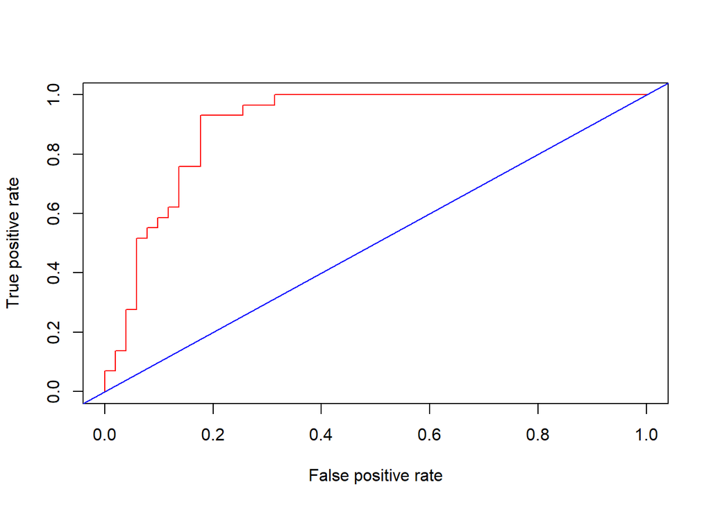

```r
plot(performance(score2, "tpr", "fpr"), col ="red")
abline(0,1, col ="blue")
```

## Question 19

```r
p_pred1 <- predict(model, newdata = test_set[c("Age")], type="response")
score1 <- prediction(p_pred1, test_set$Purchased)
auc1 <- as.numeric(performance(score1, "auc")@y.values)
auc1
```

```
## [1] 0.8739013
```

We can see that the AUC of the model1 (variable: ‘Age’) is: 0.8739013. We can see that the AUC of the model2 (variables: ‘Age’, ‘EstimatedSalary’) is: 0.8999324. So, the AUC of the model2 is higher. It means that is a better model than the model1.

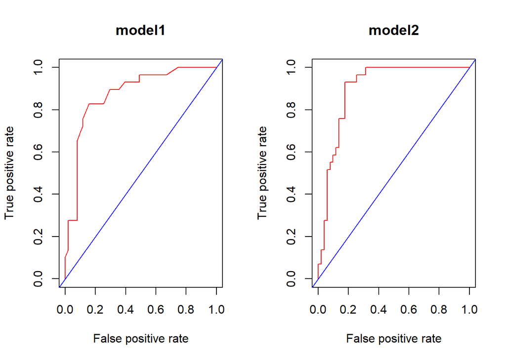

```r
par(mfrow= c(1,2))
plot(performance(score1, "tpr", "fpr"), col ="red", main= "model1")
abline(0,1, col ="blue")

plot(performance(score2, "tpr", "fpr"), col ="red", main= "model2")
abline(0,1, col ="blue")
```